# Blunt-nosed Leopard Lizard Data Analysis: Water Physiology Nuances

## Plot Delta ~ Time*Sex

### Mass

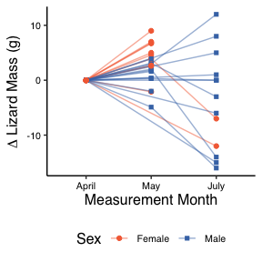

```r
ggplot(dat_tmt_change) +
  aes(x = month,
      y = mass_change_from_April,
      group = individual_ID,
      color = sex_M_F,
      shape = sex_M_F
      ) +
  xlab("Measurement Month") +
  ylab(expression(Delta ~ 'Lizard Mass (g)')) +
  geom_line(alpha = 0.5) +
  geom_point(size = 1.5) +
  scale_color_manual(values = my_colors, name = "Sex") +
  scale_shape_manual(values = my_shapes, name = "Sex") +
  savs_ggplot_theme -> delta_mass_sex
delta_mass_sex
```

### Osmolality

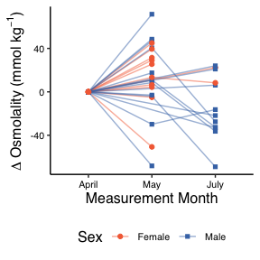

```r
ggplot(dat_tmt_change) +
  aes(x = month,
      y = osml_change_from_April,
      group = individual_ID,
      color = sex_M_F,
      shape = sex_M_F
      ) +
  xlab("Measurement Month") +
  ylab(expression(Delta ~ 'Osmolality (mmol '*kg^-1*')')) +
  geom_line(alpha = 0.5) +
  geom_point(size = 1.5) +
  scale_color_manual(values = my_colors, name = "Sex") +
  scale_shape_manual(values = my_shapes, name = "Sex") +
  savs_ggplot_theme -> delta_osml_sex
delta_osml_sex
```

### CEWL

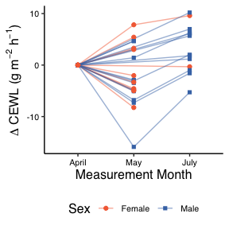

```r
ggplot(dat_tmt_change) +
  aes(x = month,
      y = CEWL_change_from_April,
      group = individual_ID,
      color = sex_M_F,
      shape = sex_M_F
      ) +
  xlab("Measurement Month") +
  ylab(expression(Delta ~ 'CEWL (g '*m^-2*' '*h^-1*')')) +
  geom_line(alpha = 0.5) +
  geom_point(size = 1.5) +
  scale_color_manual(values = my_colors, name = "Sex") +
  scale_shape_manual(values = my_shapes, name = "Sex") +
  savs_ggplot_theme -> delta_CEWL_sex
delta_CEWL_sex
```

## Export Multi-Panel Fig

Save plots:

```r
ggarrange(delta_CEWL_sex,
          delta_osml_sex,
          delta_mass_sex,
          ncol = 3, nrow = 1,
          #ncol = 1, nrow = 3,
          labels = c("A", "B", "C"),
          common.legend = TRUE,
          legend = "bottom"
          ) -> delta_multi_fig_sex
```

```r
ggsave(filename = "delta_multi_fig_sex.pdf",
       plot = delta_multi_fig_sex,
       path = "./results_figures",
       device = "pdf",
       dpi = 600,
       units = "mm",
       width = 200, height = 80
       #width = 80, height = 210
       )
```

## Time*Sex Marginal Means

I want to know whether the average values for the lizards we measured changes over time. To test this, I can run a linear model, then use emmeans to get the marginal means and confidence intervals for each time point.

**Do this only for lizards with repeat measurements.**

info for using emmeans with interactions: https://cran.r-project.org/web/packages/emmeans/vignettes/interactions.html

Check n’s:

```r
dat_repeats %>%
  group_by(month, sex_M_F) %>%
  summarise(n = n())
```

```
## # A tibble: 6 × 3
## # Groups:   month [3]
##   month sex_M_F     n
##   <fct> <fct>   <int>
## 1 April Female     11
## 2 April Male       22
## 3 May   Female     10
## 4 May   Male       17
## 5 July  Female      2
## 6 July  Male       12
```

### Mass

```r
time_sex_diffs_mass <- lmerTest::lmer(data = dat_repeats, mass_g ~ month*sex_M_F +
                                        (1|individual_ID))
anova(time_sex_diffs_mass, type = "3", ddf = "Kenward-Roger")
```

```
## Type III Analysis of Variance Table with Kenward-Roger's method
##                Sum Sq Mean Sq NumDF  DenDF F value    Pr(>F)
## month         314.003 157.002     2 38.639  9.6139 0.0004086 ***
## sex_M_F         0.032   0.032     1 38.343  0.0020 0.9647658
## month:sex_M_F  92.617  46.309     2 38.639  2.8357 0.0709404 .
## ---
## Signif. codes:  0 '***' 0.001 '**' 0.01 '*' 0.05 '.' 0.1 ' ' 1
```

```r
# mean values
emmeans_mass <- data.frame(emmeans(time_sex_diffs_mass,
                                   pairwise ~ month | sex_M_F)$emmean) %>%
  mutate(measurement = "Mass")

# stat diffs by month
time_emmeans_mass <- data.frame(emmeans(time_sex_diffs_mass,
                                   pairwise ~ month | sex_M_F)$contrasts) %>%
  mutate(measurement = "Mass")

# stat diffs by sex
sex_emmeans_mass <- data.frame(emmeans(time_sex_diffs_mass,
                                   pairwise ~ sex_M_F | month)$contrasts) %>%
  mutate(measurement = "Mass")
```

### Body Condition

```r
time_sex_diffs_SMI <- lmerTest::lmer(data = dat_repeats, SMI ~ month*sex_M_F +
                                        (1|individual_ID))
anova(time_sex_diffs_SMI, type = "3", ddf = "Kenward-Roger")
```

```
## Type III Analysis of Variance Table with Kenward-Roger's method
##               Sum Sq Mean Sq NumDF  DenDF F value    Pr(>F)
## month         327.19 163.597     2 45.863 15.2615 8.308e-06 ***
## sex_M_F         0.63   0.628     1 46.566  0.0587  0.809671
## month:sex_M_F 134.56  67.280     2 45.863  6.2764  0.003896 **
## ---
## Signif. codes:  0 '***' 0.001 '**' 0.01 '*' 0.05 '.' 0.1 ' ' 1
```

```r
# mean values
emmeans_SMI <- data.frame(emmeans(time_sex_diffs_SMI,
                                   pairwise ~ month | sex_M_F)$emmean) %>%
  mutate(measurement = "SMI")

# stat diffs by month
time_emmeans_SMI <- data.frame(emmeans(time_sex_diffs_SMI,
                                   pairwise ~ month | sex_M_F)$contrasts) %>%
  mutate(measurement = "SMI")

# stat diffs by sex
sex_emmeans_SMI <- data.frame(emmeans(time_sex_diffs_SMI,
                                   pairwise ~ sex_M_F | month)$contrasts) %>%
  mutate(measurement = "SMI")
```

### Hematocrit

```r
time_sex_diffs_hct <- lmerTest::lmer(data = dat_repeats,
                                      hematocrit_percent ~ month*sex_M_F +
                                        (1|individual_ID))
anova(time_sex_diffs_hct, type = "2", ddf = "Kenward-Roger")
```

```
## Type II Analysis of Variance Table with Kenward-Roger's method
##               Sum Sq Mean Sq NumDF  DenDF F value    Pr(>F)
## month         817.60  408.80     2 44.421 15.8405 6.412e-06 ***
## sex_M_F       169.86  169.86     1 31.941  6.5855   0.01518 *
## month:sex_M_F  21.74   10.87     2 45.442  0.4211   0.65885
## ---
## Signif. codes:  0 '***' 0.001 '**' 0.01 '*' 0.05 '.' 0.1 ' ' 1
```

```r
# mean values
emmeans_hct <- data.frame(emmeans(time_sex_diffs_hct,
                                   pairwise ~ month | sex_M_F)$emmean) %>%
  mutate(measurement = "Hematocrit")

# stat diffs by month
time_emmeans_hct <- data.frame(emmeans(time_sex_diffs_hct,
                                   pairwise ~ month | sex_M_F)$contrasts) %>%
  mutate(measurement = "Hematocrit")

# stat diffs by sex
sex_emmeans_hct <- data.frame(emmeans(time_sex_diffs_hct,
                                   pairwise ~ sex_M_F | month)$contrasts) %>%
  mutate(measurement = "Hematocrit")
```

### Osmolality

```r
time_sex_diffs_osml <- lmerTest::lmer(data = dat_repeats,
                                      osmolality_mmol_kg_mean ~ month*sex_M_F +
                                        (1|individual_ID))
```

```
## boundary (singular) fit: see help('isSingular')
```

```r
anova(time_sex_diffs_osml, type = "2", ddf = "Kenward-Roger")
```

```
## Type II Analysis of Variance Table with Kenward-Roger's method
##                Sum Sq Mean Sq NumDF  DenDF F value    Pr(>F)
## month          8073.9  4037.0     2 48.038  9.6102 0.0003086 ***
## sex_M_F       11642.2 11642.2     1 31.800 27.7401 9.302e-06 ***
## month:sex_M_F  1301.2   650.6     2 49.692  1.5476 0.2228392
## ---
## Signif. codes:  0 '***' 0.001 '**' 0.01 '*' 0.05 '.' 0.1 ' ' 1
```

```r
# mean values
emmeans_osml <- data.frame(emmeans(time_sex_diffs_osml,
                                   pairwise ~ month | sex_M_F)$emmean) %>%
  mutate(measurement = "Osmolality")

# stat diffs by month
time_emmeans_osml <- data.frame(emmeans(time_sex_diffs_osml,
                                   pairwise ~ month | sex_M_F)$contrasts) %>%
  mutate(measurement = "Osmolality")

# stat diffs by sex
sex_emmeans_osml <- data.frame(emmeans(time_sex_diffs_osml,
                                   pairwise ~ sex_M_F | month)$contrasts) %>%
  mutate(measurement = "Osmolality")
```

### CEWL

```r
time_sex_diffs_CEWL <- lmerTest::lmer(data = dat_repeats,
                                      CEWL_g_m2h ~ month*sex_M_F +
                                        (1|individual_ID))
anova(time_sex_diffs_CEWL, type = "2", ddf = "Kenward-Roger")
```

```
## Type II Analysis of Variance Table with Kenward-Roger's method
##                Sum Sq Mean Sq NumDF  DenDF F value   Pr(>F)
## month         180.393  90.197     2 44.819  8.0478 0.001032 **
## sex_M_F       103.055 103.055     1 32.419  9.1999 0.004737 **
## month:sex_M_F  18.921   9.461     2 46.365  0.8438 0.436564
## ---
## Signif. codes:  0 '***' 0.001 '**' 0.01 '*' 0.05 '.' 0.1 ' ' 1
```

```r
# check covariates
time_sex_diffs_CEWL_check_covaries <- lmerTest::lmer(data = dat_repeats,
                                                     CEWL_g_m2h ~ month*sex_M_F
                                         + msmt_temp_C + msmt_VPD_kPa +
                                        (1|individual_ID))
anova(time_sex_diffs_CEWL_check_covaries, type = "2", ddf = "Kenward-Roger") # not important at all
```

```
## Type II Analysis of Variance Table with Kenward-Roger's method
##                Sum Sq Mean Sq NumDF  DenDF F value  Pr(>F)
## month         101.714  50.857     2 50.265  4.3866 0.01754 *
## sex_M_F        89.529  89.529     1 34.970  7.7316 0.00868 **
## msmt_temp_C     0.133   0.133     1 64.720  0.0115 0.91496
## msmt_VPD_kPa    0.090   0.090     1 64.849  0.0078 0.93004
## month:sex_M_F  17.518   8.759     2 46.384  0.7555 0.47547
## ---
## Signif. codes:  0 '***' 0.001 '**' 0.01 '*' 0.05 '.' 0.1 ' ' 1
```

```r
59/0.09 # 655.5
```

```
## [1] 655.5556
```

```r
54/0.14 # 385.7
```

```
## [1] 385.7143
```

```r
# mean values
emmeans_CEWL <- data.frame(emmeans(time_sex_diffs_CEWL,
                                   pairwise ~ month | sex_M_F)$emmean) %>%
  mutate(measurement = "CEWL")

# stat diffs by month
time_emmeans_CEWL <- data.frame(emmeans(time_sex_diffs_CEWL,
                                   pairwise ~ month | sex_M_F)$contrasts) %>%
  mutate(measurement = "CEWL")

# stat diffs by sex
sex_emmeans_CEWL <- data.frame(emmeans(time_sex_diffs_CEWL,
                                   pairwise ~ sex_M_F | month)$contrasts) %>%
  mutate(measurement = "CEWL")
```

## Check Assumptions

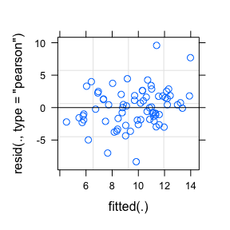

```r
plot(time_sex_diffs_CEWL)
```

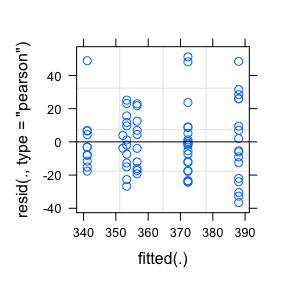

```r
plot(time_sex_diffs_osml)
```

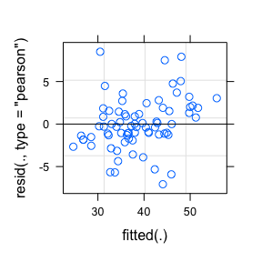

```r
plot(time_sex_diffs_mass)
```

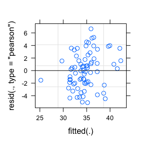

```r
plot(time_sex_diffs_SMI)
```

## Merge dfs

```r
emmeans_all <- emmeans_CEWL %>%
  rbind(emmeans_osml) %>%
  rbind(emmeans_mass) %>%
  rbind(emmeans_SMI) %>%
  mutate(month_sex = factor(paste(month, sex_M_F),
                            levels = c("April Female", "April Male",
                                       "May Female", "May Male",
                                       "July Female", "July Male")))

# all pairwise stats together
emmean_time_stats <- time_emmeans_CEWL %>%
  rbind(time_emmeans_osml) %>%
  rbind(time_emmeans_mass) %>%
  rbind(time_emmeans_SMI)
emmean_sex_stats <- sex_emmeans_CEWL %>%
  rbind(sex_emmeans_osml) %>%
  rbind(sex_emmeans_mass) %>%
  rbind(sex_emmeans_SMI)
```

## Plot MMeans ~ Time*Sex

These are plots of the marginal means, only for the dataset of lizards with repeat measurements.

### Mass

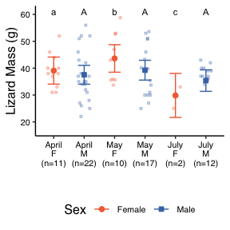

```r
ggplot() +
  geom_jitter(data = dat_repeats,
             aes(x = month_sex,
                 y = mass_g,
                 shape = sex_M_F,
                 color = sex_M_F,
                 fill = sex_M_F),
             alpha = 0.3,
             size = 0.9,
              position = position_jitter(height = 0, width = 0.2)) +
  geom_point(data = emmeans_all[emmeans_all$measurement == "Mass",],
             aes(x = month_sex,
                 y = emmean,
                 shape = sex_M_F,
                 color = sex_M_F,
                 fill = sex_M_F),
             alpha = 1,
             size = 2) +
  geom_errorbar(data = emmeans_all[emmeans_all$measurement == "Mass",],
                aes(x = month_sex,
                    y = emmean,
                    ymin = lower.CL,
                    ymax = upper.CL,
                 color = sex_M_F),
                width = .4) +
  xlab("") +
  ylab("Lizard Mass (g)") +
  # sex differences = NONE
  # time differences for MALES
  annotate(geom = "text", x = 2, y = 61, label = "A", size = 3) +
  annotate(geom = "text", x = 4, y = 61, label = "A", size = 3) +
  annotate(geom = "text", x = 6, y = 61, label = "A", size = 3) +
  # time differences for FEMALES
  annotate(geom = "text", x = 1, y = 61, label = "a", size = 3) +
  annotate(geom = "text", x = 3, y = 61, label = "b", size = 3) +
  annotate(geom = "text", x = 5, y = 61, label = "c", size = 3) +
  scale_color_manual(values = my_colors, name = "Sex") +
  scale_fill_manual(values = my_colors, name = "Sex") +
  scale_shape_manual(values = my_shapes_open, name = "Sex") +
  scale_x_discrete(labels = my_labels) +
  ylim(17, 61) +
  savs_ggplot_theme -> mass_emmean_plot
mass_emmean_plot
```

### Body Condition

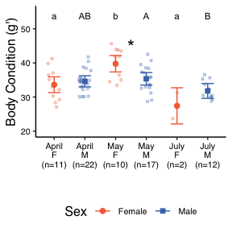

```r
ggplot() +
  geom_jitter(data = dat_repeats,
             aes(x = month_sex,
                 y = SMI,
                 shape = sex_M_F,
                 color = sex_M_F,
                 fill = sex_M_F),
             alpha = 0.3,
             size = 0.9,
              position = position_jitter(height = 0, width = 0.2)) +
  geom_point(data = emmeans_all[emmeans_all$measurement == "SMI",],
             aes(x = month_sex,
                 y = emmean,
                 shape = sex_M_F,
                 color = sex_M_F,
                 fill = sex_M_F),
             alpha = 1,
             size = 2) +
  geom_errorbar(data = emmeans_all[emmeans_all$measurement == "SMI",],
                aes(x = month_sex,
                    y = emmean,
                    ymin = lower.CL,
                    ymax = upper.CL,
                 color = sex_M_F),
                width = .4) +
  xlab("") +
  ylab("Body Condition (g')") +
  # sex differences
  annotate(geom = "text", x = 3.5, y = 45, label = "*", size = 6) +
  # time differences for MALES
  annotate(geom = "text", x = 2, y = 54, label = "AB", size = 3) +
  annotate(geom = "text", x = 4, y = 54, label = "A", size = 3) +
  annotate(geom = "text", x = 6, y = 54, label = "B", size = 3) +
  # time differences for FEMALES
  annotate(geom = "text", x = 1, y = 54, label = "a", size = 3) +
  annotate(geom = "text", x = 3, y = 54, label = "b", size = 3) +
  annotate(geom = "text", x = 5, y = 54, label = "a", size = 3) +
  scale_color_manual(values = my_colors, name = "Sex") +
  scale_fill_manual(values = my_colors, name = "Sex") +
  scale_shape_manual(values = my_shapes_open, name = "Sex") +
  scale_x_discrete(labels = my_labels) +
  ylim(20, 55) +
  savs_ggplot_theme -> SMI_emmean_plot
SMI_emmean_plot
```

### Osmolality

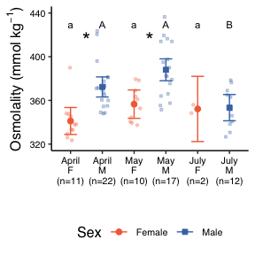

```r
ggplot() +
  geom_jitter(data = dat_repeats,
             aes(x = month_sex,
                 y = osmolality_mmol_kg_mean,
                 shape = sex_M_F,
                 color = sex_M_F,
                 fill = sex_M_F),
             alpha = 0.3,
             size = 0.9,
              position = position_jitter(height = 0, width = 0.2)) +
  geom_point(data = emmeans_all[emmeans_all$measurement == "Osmolality",],
             aes(x = month_sex,
                 y = emmean,
                 shape = sex_M_F,
                 color = sex_M_F,
                 fill = sex_M_F),
             alpha = 1,
             size = 2) +
  geom_errorbar(data = emmeans_all[emmeans_all$measurement == "Osmolality",],
                aes(x = month_sex,
                    y = emmean,
                    ymin = lower.CL,
                    ymax = upper.CL,
                 color = sex_M_F),
                width = .4) +
  xlab("") +
  ylab(bquote('Osmolality (mmol '*kg^-1*')')) +
  # sex differences
  annotate(geom = "text", x = 1.5, y = 416, label = "*", size = 6) +
  annotate(geom = "text", x = 3.5, y = 416, label = "*", size = 6) +
  # time differences for MALES
  annotate(geom = "text", x = 2, y = 430, label = "A", size = 3) +
  annotate(geom = "text", x = 4, y = 430, label = "A", size = 3) +
  annotate(geom = "text", x = 6, y = 430, label = "B", size = 3) +
  # time differences for FEMALES
  annotate(geom = "text", x = 1, y = 430, label = "a", size = 3) +
  annotate(geom = "text", x = 3, y = 430, label = "a", size = 3) +
  annotate(geom = "text", x = 5, y = 430, label = "a", size = 3) +
  scale_color_manual(values = my_colors, name = "Sex") +
  scale_fill_manual(values = my_colors, name = "Sex") +
  scale_shape_manual(values = my_shapes_open, name = "Sex") +
  scale_x_discrete(labels = my_labels) +
  scale_y_continuous(limits = c(320, 440), breaks = c(320, 360, 400, 440)) +
  savs_ggplot_theme -> osml_emmean_plot
osml_emmean_plot
```

### CEWL

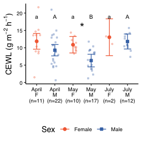

```r
ggplot() +
  geom_jitter(data = dat_repeats,
             aes(x = month_sex,
                 y = CEWL_g_m2h,
                 shape = sex_M_F,
                 color = sex_M_F,
                 fill = sex_M_F),
             alpha = 0.3,
             size = 0.9,
             position = position_jitter(height = 0, width = 0.2)) +
  geom_point(data = emmeans_all[emmeans_all$measurement == "CEWL",],
             aes(x = month_sex,
                 y = emmean,
                 shape = sex_M_F,
                 color = sex_M_F,
                 fill = sex_M_F),
             alpha = 1,
             size = 2) +
  geom_errorbar(data = emmeans_all[emmeans_all$measurement == "CEWL",],
                aes(x = month_sex,
                    y = emmean,
                    ymin = lower.CL,
                    ymax = upper.CL,
                    color = sex_M_F),
                width = .4) +
  # sex differences
  annotate(geom = "text", x = 3.5, y = 16, label = "*", size = 6) +
  # time differences for MALES
  annotate(geom = "text", x = 2, y = 19, label = "A", size = 3) +
  annotate(geom = "text", x = 4, y = 19, label = "B", size = 3) +
  annotate(geom = "text", x = 6, y = 19, label = "A", size = 3) +
  # time differences for FEMALES
  annotate(geom = "text", x = 1, y = 19, label = "a", size = 3) +
  annotate(geom = "text", x = 3, y = 19, label = "a", size = 3) +
  annotate(geom = "text", x = 5, y = 19, label = "a", size = 3) +
  xlab("") +
  ylab(bquote('CEWL (g '*m^-2*' '*h^-1*')')) +
  scale_color_manual(values = my_colors, name = "Sex") +
  scale_fill_manual(values = my_colors, name = "Sex") +
  scale_shape_manual(values = my_shapes_open, name = "Sex") +
  scale_x_discrete(labels = my_labels) +
  savs_ggplot_theme -> CEWL_emmean_plot
CEWL_emmean_plot
```

This is **only** for lizards that were recaptured and measured more than once, so I think these changes may reflect true seasonality in their water balance.

## Export Repeats-Only Multi-Panel Fig

Put in one plot together:

```r
ggarrange(CEWL_emmean_plot,
          osml_emmean_plot,
          mass_emmean_plot,
          SMI_emmean_plot,
          ncol = 4, nrow = 1,
#          ncol = 1, nrow = 3,
          labels = c("A", "B", "C", "D"),
          common.legend = TRUE,
          legend = "bottom"
          ) -> szn_change_multi_fig
#szn_change_multi_fig

ggsave(filename = "szn_change_multi_fig.pdf",
       plot = szn_change_multi_fig,
       path = "./results_figures",
       device = "pdf",
       dpi = 600,
       units = "mm",
       width = 200, height = 80
       #width = 80, height = 210
       )
```

## FULL Time*Sex Marginal Means

I’m going to do literally the same exact thing as the stats and figures in the section above, but now for **all of my data**, not just for the data on lizards with repeat measurements.

Check n’s:

```r
dat %>%
  group_by(month, sex_M_F) %>%
  summarise(n = n())
```

```
## # A tibble: 6 × 3
## # Groups:   month [3]
##   month sex_M_F     n
##   <fct> <fct>   <int>
## 1 April Female     26
## 2 April Male       41
## 3 May   Female     15
## 4 May   Male       22
## 5 July  Female      3
## 6 July  Male       12
```

### Mass

```r
full_time_sex_diffs_mass <- lmerTest::lmer(data = dat, mass_g ~ month*sex_M_F +
                                        (1|individual_ID))
full_time_sex_diffs_mass_aov <- data.frame(anova(full_time_sex_diffs_mass,
                                                 type = "2", ddf = "Kenward-Roger")) %>%
  mutate(explanatory = factor(row.names(.)))

# mean values
full_emmeans_mass <- data.frame(emmeans(full_time_sex_diffs_mass,
                                   pairwise ~ month | sex_M_F)$emmean) %>%
  mutate(measurement = "Mass")

# stat diffs by month
full_time_emmeans_mass <- data.frame(emmeans(full_time_sex_diffs_mass,
                                   pairwise ~ month | sex_M_F)$contrasts) %>%
  mutate(measurement = "Mass")

# stat diffs by sex
full_sex_emmeans_mass <- data.frame(emmeans(full_time_sex_diffs_mass,
                                   pairwise ~ sex_M_F | month)$contrasts) %>%
  mutate(measurement = "Mass")
```

### Body Condition

```r
full_time_sex_diffs_SMI <- lmerTest::lmer(data = dat, SMI ~ month*sex_M_F +
                                        (1|individual_ID))
full_time_sex_diffs_SMI_aov <- data.frame(anova(full_time_sex_diffs_SMI,
                                          type = "3", ddf = "Kenward-Roger")) %>%
  mutate(explanatory = factor(row.names(.)))

# double check that type 2 vs 3 anovas are essentially the same results
full_time_sex_diffs_SMI_aov2 <- data.frame(anova(full_time_sex_diffs_SMI,
                                          type = "2", ddf = "Kenward-Roger")) %>%
  mutate(explanatory = factor(row.names(.)))
full_time_sex_diffs_SMI_aov
```

```
##                  Sum.Sq   Mean.Sq NumDF     DenDF   F.value       Pr..F.
## month         400.48274 200.24137     2  79.56813 18.583496 2.384786e-07
## sex_M_F        11.62646  11.62646     1 102.97466  1.079132 3.013248e-01
## month:sex_M_F 138.38877  69.19439     2  79.56813  6.421618 2.597665e-03
##                 explanatory
## month                 month
## sex_M_F             sex_M_F
## month:sex_M_F month:sex_M_F
```

```r
full_time_sex_diffs_SMI_aov2
```

```
##                   Sum.Sq    Mean.Sq NumDF    DenDF   F.value       Pr..F.
## month         348.170763 174.085381     2 71.15328 16.157819 1.639477e-06
## sex_M_F         8.594231   8.594231     1 74.72959  0.797690 3.746521e-01
## month:sex_M_F 138.388775  69.194387     2 79.56813  6.421618 2.597665e-03
##                 explanatory
## month                 month
## sex_M_F             sex_M_F
## month:sex_M_F month:sex_M_F
```

```r
# mean values
full_emmeans_SMI <- data.frame(emmeans(full_time_sex_diffs_SMI,
                                   pairwise ~ month | sex_M_F)$emmean) %>%
  mutate(measurement = "SMI")

# stat diffs by month
full_time_emmeans_SMI <- data.frame(emmeans(full_time_sex_diffs_SMI,
                                   pairwise ~ month | sex_M_F)$contrasts) %>%
  mutate(measurement = "SMI")

# stat diffs by sex
full_sex_emmeans_SMI <- data.frame(emmeans(full_time_sex_diffs_SMI,
                                   pairwise ~ sex_M_F | month)$contrasts) %>%
  mutate(measurement = "SMI")
```

### Osmolality

```r
full_time_sex_diffs_osml <- lmerTest::lmer(data = dat,
                                      osmolality_mmol_kg_mean ~ month*sex_M_F +
                                        (1|individual_ID))
full_time_sex_diffs_osml_aov <- data.frame(anova(full_time_sex_diffs_osml,
                                           type = "3", ddf = "Kenward-Roger")) %>%
  mutate(explanatory = factor(row.names(.)))
full_time_sex_diffs_osml_aov2 <- data.frame(anova(full_time_sex_diffs_osml,
                                           type = "2", ddf = "Kenward-Roger")) %>%
  mutate(explanatory = factor(row.names(.)))
full_time_sex_diffs_osml_aov
```

```
##                  Sum.Sq   Mean.Sq NumDF    DenDF   F.value      Pr..F.
## month         6748.7057 3374.3528     2 91.86749 5.8321054 0.004125822
## sex_M_F       1441.1831 1441.1831     1 88.14015 2.4917205 0.118028949
## month:sex_M_F  770.2048  385.1024     2 91.86749 0.6655966 0.516427511
##                 explanatory
## month                 month
## sex_M_F             sex_M_F
## month:sex_M_F month:sex_M_F
```

```r
full_time_sex_diffs_osml_aov2
```

```
##                  Sum.Sq   Mean.Sq NumDF    DenDF   F.value       Pr..F.
## month         9627.0309 4813.5154     2 87.00381 8.3213727 0.0004933249
## sex_M_F       5545.4928 5545.4928     1 69.65080 9.5878298 0.0028217467
## month:sex_M_F  770.2048  385.1024     2 91.86749 0.6655966 0.5164275115
##                 explanatory
## month                 month
## sex_M_F             sex_M_F
## month:sex_M_F month:sex_M_F
```

```r
# mean values
full_emmeans_osml <- data.frame(emmeans(full_time_sex_diffs_osml,
                                   pairwise ~ month | sex_M_F)$emmean) %>%
  mutate(measurement = "Osmolality")

# stat diffs by month
full_time_emmeans_osml <- data.frame(emmeans(full_time_sex_diffs_osml,
                                   pairwise ~ month | sex_M_F)$contrasts) %>%
  mutate(measurement = "Osmolality")

# stat diffs by sex
full_sex_emmeans_osml <- data.frame(emmeans(full_time_sex_diffs_osml,
                                   pairwise ~ sex_M_F | month)$contrasts) %>%
  mutate(measurement = "Osmolality")
```

### CEWL

```r
full_time_sex_diffs_CEWL <- lmerTest::lmer(data = dat,
                                      CEWL_g_m2h ~ month*sex_M_F +
                                        (1|individual_ID))
full_time_sex_diffs_CEWL_aov <- data.frame(anova(full_time_sex_diffs_CEWL,
                                           type = "3", ddf = "Kenward-Roger")) %>%
  mutate(explanatory = factor(row.names(.)))
full_time_sex_diffs_CEWL_aov2 <- data.frame(anova(full_time_sex_diffs_CEWL,
                                           type = "2", ddf = "Kenward-Roger")) %>%
  mutate(explanatory = factor(row.names(.)))
full_time_sex_diffs_CEWL_aov
```

```
##                  Sum.Sq  Mean.Sq NumDF    DenDF  F.value      Pr..F.
## month         119.80851 59.90425     2 85.07588 5.625373 0.005075837
## sex_M_F        34.27453 34.27453     1 98.76587 3.219121 0.075842334
## month:sex_M_F  46.88928 23.44464     2 85.07588 2.201594 0.116890977
##                 explanatory
## month                 month
## sex_M_F             sex_M_F
## month:sex_M_F month:sex_M_F
```

```r
full_time_sex_diffs_CEWL_aov2
```

```
##                  Sum.Sq  Mean.Sq NumDF    DenDF  F.value       Pr..F.
## month         181.78030 90.89015     2 77.41997 8.536304 0.0004465354
## sex_M_F        55.19526 55.19526     1 73.45087 5.184032 0.0257090750
## month:sex_M_F  46.88928 23.44464     2 85.07588 2.201594 0.1168909770
##                 explanatory
## month                 month
## sex_M_F             sex_M_F
## month:sex_M_F month:sex_M_F
```

```r
# check covariates
full_time_sex_diffs_CEWL_check_covaries <- lmerTest::lmer(data = dat,
                                                     CEWL_g_m2h ~ month*sex_M_F
                                         + msmt_temp_C + msmt_VPD_kPa +
                                        (1|individual_ID))
anova(full_time_sex_diffs_CEWL_check_covaries,
      type = "2", ddf = "Kenward-Roger")
```

```
## Type II Analysis of Variance Table with Kenward-Roger's method
##                Sum Sq Mean Sq NumDF   DenDF F value    Pr(>F)
## month         185.755  92.878     2  89.095  8.5769 0.0003921 ***
## sex_M_F        46.450  46.450     1  74.944  4.2908 0.0417603 *
## msmt_temp_C     6.098   6.098     1 109.982  0.5633 0.4545481
## msmt_VPD_kPa    9.009   9.009     1 109.977  0.8322 0.3636216
## month:sex_M_F  32.730  16.365     2  86.160  1.5113 0.2264115
## ---
## Signif. codes:  0 '***' 0.001 '**' 0.01 '*' 0.05 '.' 0.1 ' ' 1
```

```r
# mean values
full_emmeans_CEWL <- data.frame(emmeans(full_time_sex_diffs_CEWL,
                                   pairwise ~ month | sex_M_F)$emmean) %>%
  mutate(measurement = "CEWL")

# stat diffs by month
full_time_emmeans_CEWL <- data.frame(emmeans(full_time_sex_diffs_CEWL,
                                   pairwise ~ month | sex_M_F)$contrasts) %>%
  mutate(measurement = "CEWL")

# stat diffs by sex
full_sex_emmeans_CEWL <- data.frame(emmeans(full_time_sex_diffs_CEWL,
                                   pairwise ~ sex_M_F | month)$contrasts) %>%
  mutate(measurement = "CEWL")
```

## Check Assumptions

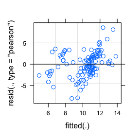

```r
plot(full_time_sex_diffs_CEWL)
```

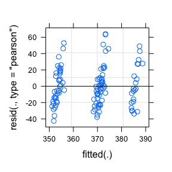

```r
plot(full_time_sex_diffs_osml)
```

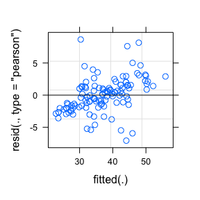

```r
plot(full_time_sex_diffs_mass)
```

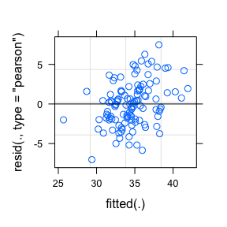

```r
plot(full_time_sex_diffs_SMI)
```

## Merge dfs

```r
full_emmeans_all <- full_emmeans_CEWL %>%
  rbind(full_emmeans_osml) %>%
  rbind(full_emmeans_mass) %>%
  rbind(full_emmeans_SMI) %>%
  mutate(month_sex = factor(paste(month, sex_M_F),
                            levels = c("April Female", "April Male",
                                       "May Female", "May Male",
                                       "July Female", "July Male")))
full_emmeans_F <- full_emmeans_all %>%
  dplyr::filter(sex_M_F == "Female")
full_emmeans_M <- full_emmeans_all %>%
  dplyr::filter(sex_M_F == "Male")

# all pairwise stats together
full_emmean_time_stats <- full_time_emmeans_CEWL %>%
  rbind(full_time_emmeans_osml) %>%
  rbind(full_time_emmeans_mass) %>%
  rbind(full_time_emmeans_SMI)
full_emmean_sex_stats <- full_sex_emmeans_CEWL %>%
  rbind(full_sex_emmeans_osml) %>%
  rbind(full_sex_emmeans_mass) %>%
  rbind(full_sex_emmeans_SMI)

# anova stats - type 2 is better for looking at interactions
full_time_sex_diffs_all <- (full_time_sex_diffs_CEWL_aov2) %>%
  rbind((full_time_sex_diffs_osml_aov2)) %>%
  #rbind((full_time_sex_diffs_mass_aov2)) %>%
  rbind((full_time_sex_diffs_SMI_aov2)) %>%
  mutate(response = factor(c(rep("CEWL", 3), rep("Plasma Osmolality", 3),
                      #rep("Mass", 3),
                      rep("Body Condition", 3))))
summary(full_time_sex_diffs_all)
```

```
##      Sum.Sq            Mean.Sq             NumDF           DenDF
##  Min.   :   8.594   Min.   :   8.594   Min.   :1.000   Min.   :69.65
##  1st Qu.:  55.195   1st Qu.:  55.195   1st Qu.:1.000   1st Qu.:73.45
##  Median : 181.780   Median :  90.890   Median :2.000   Median :77.42
##  Mean   :1857.972   Mean   :1240.613   Mean   :1.667   Mean   :78.88
##  3rd Qu.: 770.205   3rd Qu.: 385.102   3rd Qu.:2.000   3rd Qu.:85.08
##  Max.   :9627.031   Max.   :5545.493   Max.   :2.000   Max.   :91.87
##     F.value            Pr..F.                 explanatory              response
##  Min.   : 0.6656   Min.   :0.0000016   month        :3    Body Condition   :3
##  1st Qu.: 2.2016   1st Qu.:0.0004933   month:sex_M_F:3    CEWL             :3
##  Median : 6.4216   Median :0.0028217   sex_M_F      :3    Plasma Osmolality:3
##  Mean   : 6.4304   Mean   :0.1155601
##  3rd Qu.: 8.5363   3rd Qu.:0.1168910
##  Max.   :16.1578   Max.   :0.5164275
```

## Export Model Results

```r
full_time_sex_diffs_4exp <- full_time_sex_diffs_all %>%
  mutate(partial_sum_of_squares = round(Sum.Sq, 0),
         F_statistic = round(F.value, 2),
         DenDF = round(DenDF, 0),
         F_full = paste(F_statistic, " (", NumDF, ",", DenDF, ")", sep = ""),
         p_value = round(Pr..F., 4)) %>%
  dplyr::select(response, explanatory,
                partial_sum_of_squares,
                #NumDF, DenDF,
                #F_statistic,
                F_full,
                p_value)
write.csv(full_time_sex_diffs_4exp,
          "./results_statistics/hydric_Fstats_by_monthsex.csv")
```

## FULL Plot MMeans Time*Sex

### Mass

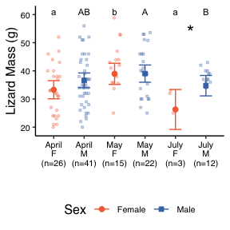

```r
ggplot() +
  geom_jitter(data = dat,
             aes(x = month_sex,
                 y = mass_g,
                 shape = sex_M_F,
                 color = sex_M_F,
                 fill = sex_M_F),
             alpha = 0.3,
             size = 0.9,
              position = position_jitter(height = 0, width = 0.2)) +
  geom_point(data = full_emmeans_all[full_emmeans_all$measurement == "Mass",],
             aes(x = month_sex,
                 y = emmean,
                 shape = sex_M_F,
                 color = sex_M_F,
                 fill = sex_M_F),
             alpha = 1,
             size = 2) +
  geom_errorbar(data = full_emmeans_all[full_emmeans_all$measurement == "Mass",],
                aes(x = month_sex,
                    y = emmean,
                    ymin = lower.CL,
                    ymax = upper.CL,
                 color = sex_M_F),
                width = .4) +
  xlab("") +
  ylab("Lizard Mass (g)") +
  # sex differences
  annotate(geom = "text", x = 5.5, y = 54, label = "*", size = 6) +
  # time differences for MALES
  annotate(geom = "text", x = 2, y = 61, label = "AB", size = 3) +
  annotate(geom = "text", x = 4, y = 61, label = "A", size = 3) +
  annotate(geom = "text", x = 6, y = 61, label = "B", size = 3) +
  # time differences for FEMALES
  annotate(geom = "text", x = 1, y = 61, label = "a", size = 3) +
  annotate(geom = "text", x = 3, y = 61, label = "b", size = 3) +
  annotate(geom = "text", x = 5, y = 61, label = "a", size = 3) +
  scale_color_manual(values = my_colors, name = "Sex") +
  scale_fill_manual(values = my_colors, name = "Sex") +
  scale_shape_manual(values = my_shapes_open, name = "Sex") +
  scale_x_discrete(labels = my_labels_full) +
  ylim(19, 61) +
  savs_ggplot_theme -> full_mass_emmean_plot
full_mass_emmean_plot
```

### Mass - F

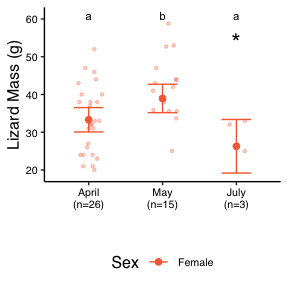

```r
ggplot() +
  geom_jitter(data = dat_F,
             aes(x = month,
                 y = mass_g,
                 shape = sex_M_F,
                 color = sex_M_F,
                 fill = sex_M_F),
             alpha = 0.3,
             size = 0.9,
              position = position_jitter(height = 0, width = 0.2)) +
  geom_point(data = full_emmeans_F[full_emmeans_F$measurement == "Mass",],
             aes(x = month,
                 y = emmean,
                 shape = sex_M_F,
                 color = sex_M_F,
                 fill = sex_M_F),
             alpha = 1,
             size = 2) +
  geom_errorbar(data = full_emmeans_F[full_emmeans_F$measurement == "Mass",],
                aes(x = month,
                    y = emmean,
                    ymin = lower.CL,
                    ymax = upper.CL,
                 color = sex_M_F),
                width = .4) +
  xlab("") +
  ylab("Lizard Mass (g)") +
  # sex differences
  annotate(geom = "text", x = 3, y = 54, label = "*", size = 6) +
  # time differences for FEMALES
  annotate(geom = "text", x = 1, y = 61, label = "a", size = 3) +
  annotate(geom = "text", x = 2, y = 61, label = "b", size = 3) +
  annotate(geom = "text", x = 3, y = 61, label = "a", size = 3) +
  scale_color_manual(values = Fem, name = "Sex") +
  scale_fill_manual(values = Fem, name = "Sex") +
  scale_shape_manual(values = 19, name = "Sex") +
  scale_x_discrete(labels = my_labels_full_F) +
  ylim(19, 61) +
  savs_ggplot_theme -> full_mass_emmean_plot_F
full_mass_emmean_plot_F
```

```r
ggsave(filename = "szn_change_mass_F_standalone.pdf",
       plot = full_mass_emmean_plot_F,
       path = "./results_figures",
       device = "pdf",
       dpi = 600,
       units = "mm",
       width = 60, height = 80
       )
```

### Mass - M

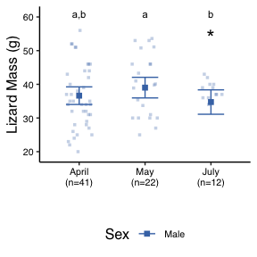

```r
ggplot() +
  geom_jitter(data = dat_M,
             aes(x = month,
                 y = mass_g,
                 shape = sex_M_F,
                 color = sex_M_F,
                 fill = sex_M_F),
             alpha = 0.3,
             size = 0.9,
              position = position_jitter(height = 0, width = 0.2)) +
  geom_point(data = full_emmeans_M[full_emmeans_M$measurement == "Mass",],
             aes(x = month,
                 y = emmean,
                 shape = sex_M_F,
                 color = sex_M_F,
                 fill = sex_M_F),
             alpha = 1,
             size = 2) +
  geom_errorbar(data = full_emmeans_M[full_emmeans_M$measurement == "Mass",],
                aes(x = month,
                    y = emmean,
                    ymin = lower.CL,
                    ymax = upper.CL,
                 color = sex_M_F),
                width = .4) +
  xlab("") +
  ylab("Lizard Mass (g)") +
  # sex differences
  annotate(geom = "text", x = 3, y = 54, label = "*", size = 6) +
  # time differences for MALES
  annotate(geom = "text", x = 1, y = 61, label = "a,b", size = 3) +
  annotate(geom = "text", x = 2, y = 61, label = "a", size = 3) +
  annotate(geom = "text", x = 3, y = 61, label = "b", size = 3) +
  scale_color_manual(values = Male, name = "Sex") +
  scale_fill_manual(values = Male, name = "Sex") +
  scale_shape_manual(values = 15, name = "Sex") +
  scale_x_discrete(labels = my_labels_full_M) +
  ylim(19, 61) +
  savs_ggplot_theme -> full_mass_emmean_plot_M
full_mass_emmean_plot_M
```

```r
ggsave(filename = "szn_change_mass_M_standalone.pdf",
       plot = full_mass_emmean_plot_M,
       path = "./results_figures",
       device = "pdf",
       dpi = 600,
       units = "mm",
       width = 60, height = 80
       )
```

### Body Condition

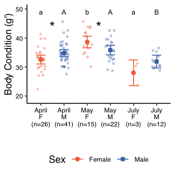

```r
ggplot() +
  geom_jitter(data = dat,
             aes(x = month_sex,
                 y = SMI,
                 shape = sex_M_F,
                 color = sex_M_F,
                 fill = sex_M_F),
             alpha = 0.3,
             size = 0.9,
              position = position_jitter(height = 0, width = 0.2)) +
  geom_point(data = full_emmeans_all[full_emmeans_all$measurement == "SMI",],
             aes(x = month_sex,
                 y = emmean,
                 shape = sex_M_F,
                 color = sex_M_F,
                 fill = sex_M_F),
             alpha = 1,
             size = 2) +
  geom_errorbar(data = full_emmeans_all[full_emmeans_all$measurement == "SMI",],
                aes(x = month_sex,
                    y = emmean,
                    ymin = lower.CL,
                    ymax = upper.CL,
                 color = sex_M_F),
                width = .4) +
  xlab("") +
  ylab("Body Condition (g')") +
  # sex differences
  annotate(geom = "text", x = 1.5, y = 44, label = "*", size = 6) +
  annotate(geom = "text", x = 3.5, y = 44, label = "*", size = 6) +
  # time differences for MALES
  annotate(geom = "text", x = 2, y = 49, label = "A", size = 3) +
  annotate(geom = "text", x = 4, y = 49, label = "A", size = 3) +
  annotate(geom = "text", x = 6, y = 49, label = "B", size = 3) +
  # time differences for FEMALES
  annotate(geom = "text", x = 1, y = 49, label = "a", size = 3) +
  annotate(geom = "text", x = 3, y = 49, label = "b", size = 3) +
  annotate(geom = "text", x = 5, y = 49, label = "a", size = 3) +
  scale_color_manual(values = my_colors, name = "Sex") +
  scale_fill_manual(values = my_colors, name = "Sex") +
  scale_shape_manual(values = my_shapes_open, name = "Sex") +
  scale_x_discrete(labels = my_labels_full) +
  ylim(19, 50) +
  savs_ggplot_theme -> full_SMI_emmean_plot
full_SMI_emmean_plot
```

### Body Cond - F

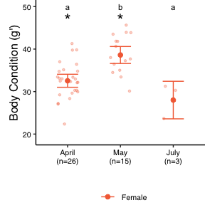

```r
ggplot() +
  geom_jitter(data = dat_F,
             aes(x = month,
                 y = SMI,
                 shape = sex_M_F,
                 color = sex_M_F,
                 fill = sex_M_F),
             alpha = 0.3,
             size = 0.9,
              position = position_jitter(height = 0, width = 0.2)) +
  geom_point(data = full_emmeans_F[full_emmeans_F$measurement == "SMI",],
             aes(x = month,
                 y = emmean,
                 shape = sex_M_F,
                 color = sex_M_F,
                 fill = sex_M_F),
             alpha = 1,
             size = 2) +
  geom_errorbar(data = full_emmeans_F[full_emmeans_F$measurement == "SMI",],
                aes(x = month,
                    y = emmean,
                    ymin = lower.CL,
                    ymax = upper.CL,
                 color = sex_M_F),
                width = .4) +
  xlab("") +
  ylab("Body Condition (g')") +
  # sex differences
  annotate(geom = "text", x = 1, y = 47, label = "*", size = 6) +
  annotate(geom = "text", x = 2, y = 47, label = "*", size = 6) +
  # time differences for FEMALES
  annotate(geom = "text", x = 1, y = 50, label = "a", size = 3) +
  annotate(geom = "text", x = 2, y = 50, label = "b", size = 3) +
  annotate(geom = "text", x = 3, y = 50, label = "a", size = 3) +
  scale_color_manual(values = Fem, name = NULL) +
  scale_fill_manual(values = Fem, name = NULL) +
  scale_shape_manual(values = 21, name = NULL) +
  scale_x_discrete(labels = my_labels_full_F) +
  ylim(19, 50) +
  savs_ggplot_theme +
  theme(plot.margin = margin(t = 0, r = 0, b = 0, l = 10, unit = "pt"),
        legend.margin = margin(0,0,0,0, unit = "pt")) -> full_SMI_emmean_plot_F
full_SMI_emmean_plot_F
```

```r
ggsave(filename = "szn_change_bodycond_F_standalone.pdf",
       plot = full_SMI_emmean_plot_F,
       path = "./results_figures",
       device = "pdf",
       dpi = 600,
       units = "mm",
       width = 60, height = 80
       )
```

### Body Cond - M

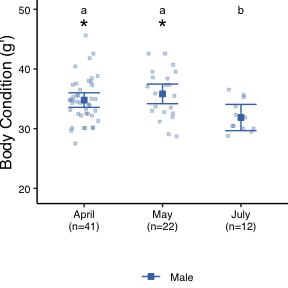

```r
ggplot() +
  geom_jitter(data = dat_M,
             aes(x = month,
                 y = SMI,
                 shape = sex_M_F,
                 color = sex_M_F,
                 fill = sex_M_F),
             alpha = 0.3,
             size = 0.9,
              position = position_jitter(height = 0, width = 0.2)) +
  geom_point(data = full_emmeans_M[full_emmeans_M$measurement == "SMI",],
             aes(x = month,
                 y = emmean,
                 shape = sex_M_F,
                 color = sex_M_F,
                 fill = sex_M_F),
             alpha = 1,
             size = 2) +
  geom_errorbar(data = full_emmeans_M[full_emmeans_M$measurement == "SMI",],
                aes(x = month,
                    y = emmean,
                    ymin = lower.CL,
                    ymax = upper.CL,
                 color = sex_M_F),
                width = .4) +
  xlab("") +
  ylab("Body Condition (g')") +
  # sex differences
  annotate(geom = "text", x = 1, y = 47, label = "*", size = 6) +
  annotate(geom = "text", x = 2, y = 47, label = "*", size = 6) +
  # time differences for MALES
  annotate(geom = "text", x = 1, y = 50, label = "a", size = 3) +
  annotate(geom = "text", x = 2, y = 50, label = "a", size = 3) +
  annotate(geom = "text", x = 3, y = 50, label = "b", size = 3) +
  scale_color_manual(values = Male, name = NULL) +
  scale_fill_manual(values = Male, name = NULL) +
  scale_shape_manual(values = 22, name = NULL) +
  scale_x_discrete(labels = my_labels_full_M) +
  ylim(19, 50) +
  savs_ggplot_theme  +
  theme(plot.margin = margin(t = 0, r = 0, b = 0, l = 0, unit = "pt"),
        legend.margin = margin(0,0,0,0, unit = "pt")) -> full_SMI_emmean_plot_M
full_SMI_emmean_plot_M
```

```r
ggsave(filename = "szn_change_bodycond_M_standalone.pdf",
       plot = full_SMI_emmean_plot_M,
       path = "./results_figures",
       device = "pdf",
       dpi = 600,
       units = "mm",
       width = 60, height = 80
       )
```

### Osmolality

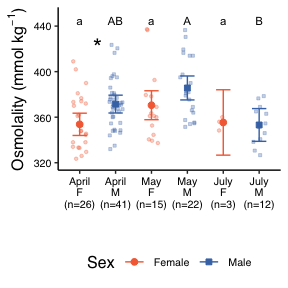

```r
ggplot() +
  geom_jitter(data = dat,
             aes(x = month_sex,
                 y = osmolality_mmol_kg_mean,
                 shape = sex_M_F,
                 color = sex_M_F,
                 fill = sex_M_F),
             alpha = 0.3,
             size = 0.9,
              position = position_jitter(height = 0, width = 0.2)) +
  geom_point(data = full_emmeans_all[full_emmeans_all$measurement == "Osmolality",],
             aes(x = month_sex,
                 y = emmean,
                 shape = sex_M_F,
                 color = sex_M_F,
                 fill = sex_M_F),
             alpha = 1,
             size = 2) +
  geom_errorbar(data = full_emmeans_all[full_emmeans_all$measurement == "Osmolality",],
                aes(x = month_sex,
                    y = emmean,
                    ymin = lower.CL,
                    ymax = upper.CL,
                 color = sex_M_F),
                width = .4) +
  xlab("") +
  ylab(bquote('Osmolality (mmol '*kg^-1*')')) +
  # sex differences
  annotate(geom = "text", x = 1.5, y = 422, label = "*", size = 6) +
  # time differences for MALES
  annotate(geom = "text", x = 2, y = 445, label = "AB", size = 3) +
  annotate(geom = "text", x = 4, y = 445, label = "A", size = 3) +
  annotate(geom = "text", x = 6, y = 445, label = "B", size = 3) +
  # time differences for FEMALES
  annotate(geom = "text", x = 1, y = 445, label = "a", size = 3) +
  annotate(geom = "text", x = 3, y = 445, label = "a", size = 3) +
  annotate(geom = "text", x = 5, y = 445, label = "a", size = 3) +
  scale_color_manual(values = my_colors, name = "Sex") +
  scale_fill_manual(values = my_colors, name = "Sex") +
  scale_shape_manual(values = my_shapes_open, name = "Sex") +
  scale_x_discrete(labels = my_labels_full) +
  scale_y_continuous(limits = c(320, 450), breaks = c(320, 360, 400, 440)) +
  savs_ggplot_theme -> full_osml_emmean_plot
full_osml_emmean_plot
```

### Osmolality - F

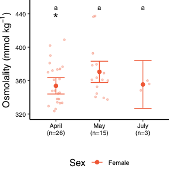

```r
ggplot() +
  geom_jitter(data = dat_F,
             aes(x = month,
                 y = osmolality_mmol_kg_mean,
                 shape = sex_M_F,
                 color = sex_M_F,
                 fill = sex_M_F),
             alpha = 0.3,
             size = 0.9,
              position = position_jitter(height = 0, width = 0.2)) +
  geom_point(data = full_emmeans_F[full_emmeans_F$measurement == "Osmolality",],
             aes(x = month,
                 y = emmean,
                 shape = sex_M_F,
                 color = sex_M_F,
                 fill = sex_M_F),
             alpha = 1,
             size = 2) +
  geom_errorbar(data = full_emmeans_F[full_emmeans_F$measurement == "Osmolality",],
                aes(x = month,
                    y = emmean,
                    ymin = lower.CL,
                    ymax = upper.CL,
                 color = sex_M_F),
                width = .4) +
  xlab("") +
  ylab(bquote('Osmolality (mmol '*kg^-1*')')) +
  # sex differences
  annotate(geom = "text", x = 1, y = 435, label = "*", size = 6) +
  # time differences for FEMALES
  annotate(geom = "text", x = 1, y = 448, label = "a", size = 3) +
  annotate(geom = "text", x = 2, y = 448, label = "a", size = 3) +
  annotate(geom = "text", x = 3, y = 448, label = "a", size = 3) +
  scale_color_manual(values = Fem, name = "Sex") +
  scale_fill_manual(values = Fem, name = "Sex") +
  scale_shape_manual(values = 21, name = "Sex") +
  scale_x_discrete(labels = my_labels_full_F) +
  scale_y_continuous(limits = c(320, 450), breaks = c(320, 360, 400, 440)) +
  savs_ggplot_theme +
  theme(plot.margin = margin(t = 0, r = 0, b = 0, l = 0, unit = "pt"),
        legend.margin = margin(0,0,0,0, unit = "pt")) -> full_osml_emmean_plot_F
full_osml_emmean_plot_F
```

```r
ggsave(filename = "szn_change_osml_F_standalone.pdf",
       plot = full_osml_emmean_plot_F,
       path = "./results_figures",
       device = "pdf",
       dpi = 600,
       units = "mm",
       width = 60, height = 80
       )
```

### Osmolality - M

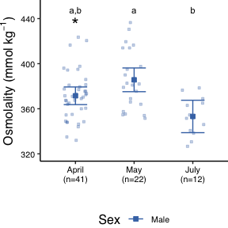

```r
ggplot() +
  geom_jitter(data = dat_M,
             aes(x = month,
                 y = osmolality_mmol_kg_mean,
                 shape = sex_M_F,
                 color = sex_M_F,
                 fill = sex_M_F),
             alpha = 0.3,
             size = 0.9,
              position = position_jitter(height = 0, width = 0.2)) +
  geom_point(data = full_emmeans_M[full_emmeans_M$measurement == "Osmolality",],
             aes(x = month,
                 y = emmean,
                 shape = sex_M_F,
                 color = sex_M_F,
                 fill = sex_M_F),
             alpha = 1,
             size = 2) +
  geom_errorbar(data = full_emmeans_M[full_emmeans_M$measurement == "Osmolality",],
                aes(x = month,
                    y = emmean,
                    ymin = lower.CL,
                    ymax = upper.CL,
                 color = sex_M_F),
                width = .4) +
  xlab("") +
  ylab(bquote('Osmolality (mmol '*kg^-1*')')) +
  # sex differences
  annotate(geom = "text", x = 1, y = 435, label = "*", size = 6) +
  # time differences for MALES
  annotate(geom = "text", x = 1, y = 448, label = "a,b", size = 3) +
  annotate(geom = "text", x = 2, y = 448, label = "a", size = 3) +
  annotate(geom = "text", x = 3, y = 448, label = "b", size = 3) +
  scale_color_manual(values = Male, name = "Sex") +
  scale_fill_manual(values = Male, name = "Sex") +
  scale_shape_manual(values = 22, name = "Sex") +
  scale_x_discrete(labels = my_labels_full_M) +
  scale_y_continuous(limits = c(320, 450), breaks = c(320, 360, 400, 440)) +
  savs_ggplot_theme +
  theme(plot.margin = margin(t = 0, r = 0, b = 0, l = 0, unit = "pt"),
        legend.margin = margin(0,0,0,0, unit = "pt")) -> full_osml_emmean_plot_M
full_osml_emmean_plot_M
```

```r
ggsave(filename = "szn_change_osml_M_standalone.pdf",
       plot = full_osml_emmean_plot_M,
       path = "./results_figures",
       device = "pdf",
       dpi = 600,
       units = "mm",
       width = 60, height = 80
       )
```

### CEWL

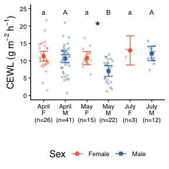

```r
ggplot() +
  geom_jitter(data = dat,
             aes(x = month_sex,
                 y = CEWL_g_m2h,
                 shape = sex_M_F,
                 color = sex_M_F,
                 fill = sex_M_F),
             alpha = 0.3,
             size = 0.9,
             position = position_jitter(height = 0, width = 0.2)) +
  geom_point(data = full_emmeans_all[full_emmeans_all$measurement == "CEWL",],
             aes(x = month_sex,
                 y = emmean,
                 shape = sex_M_F,
                 color = sex_M_F,
                 fill = sex_M_F),
             alpha = 1,
             size = 2) +
  geom_errorbar(data = full_emmeans_all[full_emmeans_all$measurement == "CEWL",],
                aes(x = month_sex,
                    y = emmean,
                    ymin = lower.CL,
                    ymax = upper.CL,
                    color = sex_M_F),
                width = .4) +
  # sex differences
  annotate(geom = "text", x = 3.5, y = 20, label = "*", size = 6) +
  # time differences for MALES
  annotate(geom = "text", x = 2, y = 24, label = "A", size = 3) +
  annotate(geom = "text", x = 4, y = 24, label = "B", size = 3) +
  annotate(geom = "text", x = 6, y = 24, label = "A", size = 3) +
  # time differences for FEMALES = none
  annotate(geom = "text", x = 1, y = 24, label = "a", size = 3) +
  annotate(geom = "text", x = 3, y = 24, label = "a", size = 3) +
  annotate(geom = "text", x = 5, y = 24, label = "a", size = 3) +
  xlab("") +
  ylab(bquote('CEWL (g '*m^-2*' '*h^-1*')')) +
  ylim(0, 25) +
  scale_color_manual(values = my_colors, name = "Sex") +
  scale_fill_manual(values = my_colors, name = "Sex") +
  scale_shape_manual(values = my_shapes_open, name = "Sex") +
  scale_x_discrete(labels = my_labels_full) +
  savs_ggplot_theme -> full_CEWL_emmean_plot
full_CEWL_emmean_plot
```

### CEWL - F

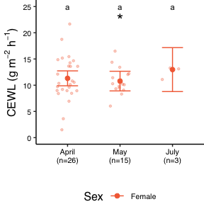

```r
ggplot() +
  geom_jitter(data = dat_F,
             aes(x = month,
                 y = CEWL_g_m2h,
                 shape = sex_M_F,
                 color = sex_M_F,
                 fill = sex_M_F),
             alpha = 0.3,
             size = 0.9,
             position = position_jitter(height = 0, width = 0.2)) +
  geom_point(data = full_emmeans_F[full_emmeans_F$measurement == "CEWL",],
             aes(x = month,
                 y = emmean,
                 shape = sex_M_F,
                 color = sex_M_F,
                 fill = sex_M_F),
             alpha = 1,
             size = 2) +
  geom_errorbar(data = full_emmeans_F[full_emmeans_F$measurement == "CEWL",],
                aes(x = month,
                    y = emmean,
                    ymin = lower.CL,
                    ymax = upper.CL,
                    color = sex_M_F),
                width = .4) +
  # sex differences
  annotate(geom = "text", x = 2, y = 22.5, label = "*", size = 6) +
  # time differences for FEMALES = none
  annotate(geom = "text", x = 1, y = 25, label = "a", size = 3) +
  annotate(geom = "text", x = 2, y = 25, label = "a", size = 3) +
  annotate(geom = "text", x = 3, y = 25, label = "a", size = 3) +
  xlab("") +
  ylab(bquote('CEWL (g '*m^-2*' '*h^-1*')')) +
  ylim(0, 25) +
  scale_color_manual(values = Fem, name = "Sex") +
  scale_fill_manual(values = Fem, name = "Sex") +
  scale_shape_manual(values = 21, name = "Sex") +
  scale_x_discrete(labels = my_labels_full_F) +
  savs_ggplot_theme +
  theme(plot.margin = margin(t = 0, r = 0, b = 0, l = 4.5, unit = "pt"),
        legend.margin = margin(0,0,0,0, unit = "pt")) -> full_CEWL_emmean_plot_F
full_CEWL_emmean_plot_F
```

```r
ggsave(filename = "szn_change_CEWL_F_standalone.pdf",
       plot = full_CEWL_emmean_plot_F,
       path = "./results_figures",
       device = "pdf",
       dpi = 600,
       units = "mm",
       width = 60, height = 80
       )
```

### CEWL - M

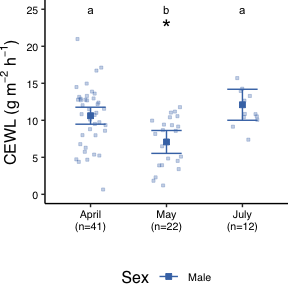

```r
ggplot() +
  geom_jitter(data = dat_M,
             aes(x = month,
                 y = CEWL_g_m2h,
                 shape = sex_M_F,
                 color = sex_M_F,
                 fill = sex_M_F),
             alpha = 0.3,
             size = 0.9,
             position = position_jitter(height = 0, width = 0.2)) +
  geom_point(data = full_emmeans_M[full_emmeans_M$measurement == "CEWL",],
             aes(x = month,
                 y = emmean,
                 shape = sex_M_F,
                 color = sex_M_F,
                 fill = sex_M_F),
             alpha = 1,
             size = 2) +
  geom_errorbar(data = full_emmeans_M[full_emmeans_M$measurement == "CEWL",],
                aes(x = month,
                    y = emmean,
                    ymin = lower.CL,
                    ymax = upper.CL,
                    color = sex_M_F),
                width = .4) +
  # sex differences
  annotate(geom = "text", x = 2, y = 22.5, label = "*", size = 6) +
  # time differences for MALES
  annotate(geom = "text", x = 1, y = 25, label = "a", size = 3) +
  annotate(geom = "text", x = 2, y = 25, label = "b", size = 3) +
  annotate(geom = "text", x = 3, y = 25, label = "a", size = 3) +
  xlab("") +
  ylab(bquote('CEWL (g '*m^-2*' '*h^-1*')')) +
  ylim(0, 25) +
  scale_color_manual(values = Male, name = "Sex") +
  scale_fill_manual(values = Male, name = "Sex") +
  scale_shape_manual(values = 22, name = "Sex") +
  scale_x_discrete(labels = my_labels_full_M) +
  savs_ggplot_theme +
  theme(plot.margin = margin(t = 0, r = 0, b = 0, l = 0, unit = "pt"),
        legend.margin = margin(0,0,0,0, unit = "pt")) -> full_CEWL_emmean_plot_M
full_CEWL_emmean_plot_M
```

```r
ggsave(filename = "szn_change_CEWL_M_standalone.pdf",
       plot = full_CEWL_emmean_plot_M,
       path = "./results_figures",
       device = "pdf",
       dpi = 600,
       units = "mm",
       width = 60, height = 80
       )
```

## Arrange and Export M&F Separate Panel Plot

```r
# CEWL
full_CEWL_emmean_plot_M_multi <- full_CEWL_emmean_plot_M +
  theme(axis.text.y = element_blank(),
        axis.ticks.y = element_blank(),
        axis.text.x = element_blank(),
        axis.ticks.x = element_blank(),
        legend.position = "none") +
  labs(y = NULL)
full_CEWL_emmean_plot_F_multi <- full_CEWL_emmean_plot_F +
  theme(axis.text.x = element_blank(),
        axis.ticks.x = element_blank(),
        legend.position = "none")
# osmolality
full_osml_emmean_plot_M_multi <- full_osml_emmean_plot_M +
  theme(axis.text.y = element_blank(),
        axis.ticks.y = element_blank(),
        axis.text.x = element_blank(),
        axis.ticks.x = element_blank(),
        legend.position = "none") +
  labs(y = NULL)
full_osml_emmean_plot_F_multi <- full_osml_emmean_plot_F +
  theme(axis.text.x = element_blank(),
        axis.ticks.x = element_blank(),
        legend.position = "none")
# body condition
full_SMI_emmean_plot_M_multi <- full_SMI_emmean_plot_M +
  theme(axis.text.y = element_blank(),
        axis.ticks.y = element_blank()) +
  labs(y = NULL)

# arrange M & F together
ggarrange(full_CEWL_emmean_plot_F_multi, full_CEWL_emmean_plot_M_multi,
          full_osml_emmean_plot_F_multi, full_osml_emmean_plot_M_multi,
          full_SMI_emmean_plot_F, full_SMI_emmean_plot_M_multi,
          ncol = 2, nrow = 3,
          widths = c(1.36, 1), # make x-axis widths match when exported
          heights = c(1, 1, 1.29), # heights
          labels = c("(a)", "", "(b)", "", "(c)", ""),
          label.y = c(1.02, 1.02, 1.02),
          font.label = list(color = "black", face = "bold", size = 12)
          ) -> full_szn_change_multi_fig
#full_szn_change_multi_fig

ggsave(filename = "szn_change_multi_fig.pdf",
       plot = full_szn_change_multi_fig,
       path = "./results_figures",
       device = "pdf",
       dpi = 600,
       units = "mm",
       width = 80, height = 190 # don't change bc might mess up relative sizing
       )
```

## Export Full Data Multi-Panel Fig

```r
ggarrange(full_CEWL_emmean_plot,
          full_osml_emmean_plot,
          #full_mass_emmean_plot,
          full_SMI_emmean_plot,
          ncol = 3, nrow = 1,
          #ncol = 1, nrow = 3,
          labels = c("A", "B", "C"),
          common.legend = TRUE,
          legend = "bottom"
          ) -> full_szn_change_multi_fig
#full_szn_change_multi_fig

ggsave(filename = "szn_change_multi_fig_full_horizontal.pdf",
       plot = full_szn_change_multi_fig,
       path = "./results_figures",
       device = "pdf",
       dpi = 600,
       units = "mm",
       width = 220, height = 80
       #width = 80, height = 210
       )
```

## Export Full & Repeats Multi-Panel Fig

```r
ggarrange(full_CEWL_emmean_plot,
          full_osml_emmean_plot,
          full_mass_emmean_plot,
          full_SMI_emmean_plot,
          CEWL_emmean_plot,
          osml_emmean_plot,
          mass_emmean_plot,
          SMI_emmean_plot,
          ncol = 4, nrow = 2,
#          ncol = 1, nrow = 3,
          labels = c("full", "full", "full", "full",
                     "rep", "rep", "rep", "rep"),
          common.legend = TRUE,
          legend = "bottom"
          ) -> full_vs_rep_szn_change_multi_fig
#full_vs_rep_szn_change_multi_fig

#ggsave(filename = "szn_change_multi_fig_full_vs_rep.pdf",
 #      plot = full_vs_rep_szn_change_multi_fig,
  #     path = "./results_figures",
   #    device = "pdf",
    #   dpi = 600,
     #  units = "mm",
      # width = 210, height = 160
       ##width = 80, height = 210
       #)
```

# Reproductive Effort

Is reproductive effort related to water balance?

## Egg Investment

```r
summary(dat_repeat_females)
```

```
##  capture_date_time                 capture_date        radio_collar_serial
##  Min.   :2021-04-23 04:39:00.00   Min.   :2021-04-23   Length:18
##  1st Qu.:2021-04-23 08:07:30.00   1st Qu.:2021-04-23   Class :character
##  Median :2021-04-24 05:51:30.00   Median :2021-05-01   Mode  :character
##  Mean   :2021-04-29 23:59:56.25   Mean   :2021-04-30
##  3rd Qu.:2021-05-08 02:32:30.00   3rd Qu.:2021-05-08
##  Max.   :2021-05-08 05:27:00.00   Max.   :2021-05-08
##  NA's   :2
##   PIT_tag_ID        individual_ID   sex_M_F       mass_g          SVL_mm
##  Length:18          F-01   :2     Female:18   Min.   :31.00   Min.   : 90.0
##  Class :character   F-03   :2     Male  : 0   1st Qu.:35.60   1st Qu.: 95.0
##  Mode  :character   F-05   :2                 Median :40.00   Median :100.0
##                     F-06   :2                 Mean   :41.73   Mean   :100.7
##                     F-11   :2                 3rd Qu.:46.75   3rd Qu.:106.5
##                     F-12   :2                 Max.   :58.80   Max.   :114.0
##                     (Other):6
##         tmt     tmt_mass_change_g capture_to_msmt   hematocrit_percent
##  Water Tmt: 8   Min.   :-3.0000   Min.   :  25.00   Min.   :23.00
##  Sham Tmt :10   1st Qu.:-1.4000   1st Qu.:  55.25   1st Qu.:30.25
##  No Tmt   : 0   Median :-0.1000   Median : 147.00   Median :32.50
##                 Mean   :-0.5941   Mean   : 225.88   Mean   :33.78
##                 3rd Qu.: 0.0000   3rd Qu.: 247.00   3rd Qu.:37.00
##                 Max.   : 1.8000   Max.   :1638.00   Max.   :44.00
##                 NA's   :1         NA's   :2
##  cloacal_temp_C    CEWL_g_m2h      msmt_temp_C    msmt_RH_percent
##  Min.   :28.00   Min.   : 1.493   Min.   :23.13   Min.   :12.20
##  1st Qu.:33.25   1st Qu.: 8.986   1st Qu.:30.47   1st Qu.:14.19
##  Median :34.00   Median :10.320   Median :31.59   Median :14.90
##  Mean   :33.72   Mean   :11.109   Mean   :30.79   Mean   :16.29
##  3rd Qu.:35.00   3rd Qu.:13.559   3rd Qu.:31.89   3rd Qu.:18.02
##  Max.   :36.00   Max.   :21.673   Max.   :32.23   Max.   :28.17
##
##     e_s_kPa       msmt_VPD_kPa   osmolality_mmol_kg_mean   month   week
##  Min.   :2.830   Min.   :2.033   Min.   :329.5           April:9   1 :9
##  1st Qu.:4.358   1st Qu.:3.692   1st Qu.:338.0           May  :9   3 :9
##  Median :4.646   Median :3.916   Median :345.0           July :0   12:0
##  Mean   :4.463   Mean   :3.751   Mean   :350.9
##  3rd Qu.:4.725   3rd Qu.:4.054   3rd Qu.:362.9
##  Max.   :4.818   Max.   :4.167   Max.   :390.0
##
```

[output cut: 17 more lines]

```
##  Min.   :1.00   Min.   :29.24   April Female:9   Apr 23-25:9
##  1st Qu.:2.00   1st Qu.:34.63   April Male  :0   May 7-9  :9
##  Median :2.00   Median :36.73   May Female  :9   Jul 14   :0
##  Mean   :2.75   Mean   :37.83   May Male    :0
##  3rd Qu.:3.25   3rd Qu.:41.85   July Female :0
##  Max.   :5.00   Max.   :45.63   July Male   :0
##  NA's   :6
##  percent_water_mass_change n
##  Min.   :-6.834            2:18
##  1st Qu.:-4.242            1: 0
##  Median :-0.250
##  Mean   :-1.539
##  3rd Qu.: 0.000
##  Max.   : 3.462
##  NA's   :1
```

```r
dat_repeat_females_eggs <- dat_repeat_females %>%
  dplyr::filter(gravid_Y_N == "Gravid") %>%
  dplyr::filter(month == "May") # so we don't have any repeats

summary(lm(data = dat_repeat_females_eggs, number_eggs ~ mass_g))
```

```
##
## Call:
## lm(formula = number_eggs ~ mass_g, data = dat_repeat_females_eggs)
##
## Residuals:
##     Min      1Q  Median      3Q     Max
## -0.2855 -0.2647 -0.1891  0.1467  0.7541
##
## Coefficients:
##             Estimate Std. Error t value Pr(>|t|)
## (Intercept)  1.11895    0.69935   1.600   0.1607
## mass_g       0.05975    0.01554   3.846   0.0085 **
## ---
## Signif. codes:  0 '***' 0.001 '**' 0.01 '*' 0.05 '.' 0.1 ' ' 1
##
## Residual standard error: 0.4103 on 6 degrees of freedom
## Multiple R-squared:  0.7114, Adjusted R-squared:  0.6633
## F-statistic: 14.79 on 1 and 6 DF,  p-value: 0.008501
```

```r
summary(lm(data = dat_repeat_females_eggs, number_eggs ~ SVL_mm))
```

```
##
## Call:
## lm(formula = number_eggs ~ SVL_mm, data = dat_repeat_females_eggs)
##
## Residuals:
##      Min       1Q   Median       3Q      Max
## -0.38064 -0.30282 -0.00921  0.28214  0.44492
##
## Coefficients:
##             Estimate Std. Error t value Pr(>|t|)
## (Intercept) -5.43434    2.07306  -2.621  0.03951 *
## SVL_mm       0.09173    0.02066   4.439  0.00438 **
## ---
## Signif. codes:  0 '***' 0.001 '**' 0.01 '*' 0.05 '.' 0.1 ' ' 1
##
## Residual standard error: 0.369 on 6 degrees of freedom
## Multiple R-squared:  0.7666, Adjusted R-squared:  0.7277
## F-statistic: 19.71 on 1 and 6 DF,  p-value: 0.00438
```

```r
summary(lm(data = dat_repeat_females_eggs, number_eggs ~ SMI))
```

```
##
## Call:
## lm(formula = number_eggs ~ SMI, data = dat_repeat_females_eggs)
##
## Residuals:
##     Min      1Q  Median      3Q     Max
## -0.9073 -0.3127 -0.0824  0.2596  0.9036
##
## Coefficients:
##             Estimate Std. Error t value Pr(>|t|)
## (Intercept)  0.04386    2.40577   0.018    0.986
## SMI          0.09238    0.05970   1.548    0.173
##
## Residual standard error: 0.6457 on 6 degrees of freedom
## Multiple R-squared:  0.2853, Adjusted R-squared:  0.1661
## F-statistic: 2.395 on 1 and 6 DF,  p-value: 0.1727
```

```r
anova(lm(data = dat_repeat_females_eggs, number_eggs ~ mass_g))
```

```
## Analysis of Variance Table
##
## Response: number_eggs
##           Df Sum Sq Mean Sq F value   Pr(>F)
## mass_g     1 2.4899 2.48991   14.79 0.008501 **
## Residuals  6 1.0101 0.16835
## ---
## Signif. codes:  0 '***' 0.001 '**' 0.01 '*' 0.05 '.' 0.1 ' ' 1
```

```r
anova(lm(data = dat_repeat_females_eggs, number_eggs ~ SVL_mm))
```

```
## Analysis of Variance Table
##
## Response: number_eggs
##           Df  Sum Sq Mean Sq F value  Pr(>F)
## SVL_mm     1 2.68307 2.68307  19.706 0.00438 **
## Residuals  6 0.81693 0.13616
## ---
## Signif. codes:  0 '***' 0.001 '**' 0.01 '*' 0.05 '.' 0.1 ' ' 1
```

## Repeat Individuals

I have 9 females measured at both April and May time points. Let’s see if their physiology changes consistently based on becoming gravid.

First, calculate the change in CEWL, osmolality, and mass for each of those females between April to May.

```r
fem_starting_values <- dat_repeat_females %>%
  # get the values for April measurements only
  dplyr::filter(month == "April") %>%
  dplyr::select(individual_ID,
                CEWL_April = CEWL_g_m2h,
                osml_April = osmolality_mmol_kg_mean,
                mass_April = mass_g,
                SMI_April = SMI)
fem_change <- dat_repeat_females %>%
  # add starting values
  left_join(fem_starting_values, by = 'individual_ID') %>%
  # make sure we have complete data
  dplyr::filter(complete.cases(mass_April, CEWL_April)) %>%
  # calculate difference for each msmt versus in April
  mutate(mass_change_from_April = mass_g - mass_April,
         SMI_change_from_April = SMI - SMI_April,
         CEWL_change_from_April = CEWL_g_m2h - CEWL_April,
         osml_change_from_April = osmolality_mmol_kg_mean - osml_April)
summary(fem_change)
```

```
##  capture_date_time                 capture_date        radio_collar_serial
##  Min.   :2021-04-23 04:39:00.00   Min.   :2021-04-23   Length:18
##  1st Qu.:2021-04-23 08:07:30.00   1st Qu.:2021-04-23   Class :character
##  Median :2021-04-24 05:51:30.00   Median :2021-05-01   Mode  :character
##  Mean   :2021-04-29 23:59:56.25   Mean   :2021-04-30
##  3rd Qu.:2021-05-08 02:32:30.00   3rd Qu.:2021-05-08
##  Max.   :2021-05-08 05:27:00.00   Max.   :2021-05-08
##  NA's   :2
##   PIT_tag_ID        individual_ID   sex_M_F       mass_g          SVL_mm
##  Length:18          F-01   :2     Female:18   Min.   :31.00   Min.   : 90.0
##  Class :character   F-03   :2     Male  : 0   1st Qu.:35.60   1st Qu.: 95.0
##  Mode  :character   F-05   :2                 Median :40.00   Median :100.0
##                     F-06   :2                 Mean   :41.73   Mean   :100.7
##                     F-11   :2                 3rd Qu.:46.75   3rd Qu.:106.5
##                     F-12   :2                 Max.   :58.80   Max.   :114.0
##                     (Other):6
##         tmt     tmt_mass_change_g capture_to_msmt   hematocrit_percent
##  Water Tmt: 8   Min.   :-3.0000   Min.   :  25.00   Min.   :23.00
##  Sham Tmt :10   1st Qu.:-1.4000   1st Qu.:  55.25   1st Qu.:30.25
##  No Tmt   : 0   Median :-0.1000   Median : 147.00   Median :32.50
##                 Mean   :-0.5941   Mean   : 225.88   Mean   :33.78
##                 3rd Qu.: 0.0000   3rd Qu.: 247.00   3rd Qu.:37.00
##                 Max.   : 1.8000   Max.   :1638.00   Max.   :44.00
##                 NA's   :1         NA's   :2
##  cloacal_temp_C    CEWL_g_m2h      msmt_temp_C    msmt_RH_percent
##  Min.   :28.00   Min.   : 1.493   Min.   :23.13   Min.   :12.20
##  1st Qu.:33.25   1st Qu.: 8.986   1st Qu.:30.47   1st Qu.:14.19
##  Median :34.00   Median :10.320   Median :31.59   Median :14.90
##  Mean   :33.72   Mean   :11.109   Mean   :30.79   Mean   :16.29
##  3rd Qu.:35.00   3rd Qu.:13.559   3rd Qu.:31.89   3rd Qu.:18.02
##  Max.   :36.00   Max.   :21.673   Max.   :32.23   Max.   :28.17
##
##     e_s_kPa       msmt_VPD_kPa   osmolality_mmol_kg_mean   month   week
##  Min.   :2.830   Min.   :2.033   Min.   :329.5           April:9   1 :9
##  1st Qu.:4.358   1st Qu.:3.692   1st Qu.:338.0           May  :9   3 :9
##  Median :4.646   Median :3.916   Median :345.0           July :0   12:0
##  Mean   :4.463   Mean   :3.751   Mean   :350.9
##  3rd Qu.:4.725   3rd Qu.:4.054   3rd Qu.:362.9
##  Max.   :4.818   Max.   :4.167   Max.   :390.0
##
```

[output cut: 33 more lines]

```
##  Min.   :31.00   Min.   :29.24   Min.   :-2.100         Min.   :-0.6421
##  1st Qu.:33.00   1st Qu.:32.19   1st Qu.: 0.000         1st Qu.: 0.0000
##  Median :40.00   Median :35.13   Median : 0.000         Median : 0.0000
##  Mean   :39.44   Mean   :34.93   Mean   : 2.289         Mean   : 2.8985
##  3rd Qu.:44.00   3rd Qu.:37.02   3rd Qu.: 4.425         3rd Qu.: 3.8356
##  Max.   :52.00   Max.   :41.30   Max.   : 9.000         Max.   :14.2653
##
##  CEWL_change_from_April osml_change_from_April
##  Min.   :-8.2493        Min.   :-50.667
##  1st Qu.:-1.5265        1st Qu.:  0.000
##  Median : 0.0000        Median :  0.000
##  Mean   :-0.1947        Mean   :  6.111
##  3rd Qu.: 0.0000        3rd Qu.: 11.625
##  Max.   : 7.8247        Max.   : 45.000
##
```

## Plot Indiv Change

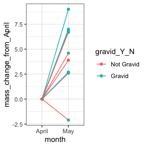

```r
ggplot(fem_change) +
  aes(x = month,
      y = mass_change_from_April,
      group = individual_ID,
      color = gravid_Y_N
      ) +
  geom_point() +
  geom_line() +
  theme_bw()
```

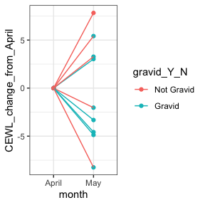

```r
ggplot(fem_change) +
  aes(x = month,
      y = CEWL_change_from_April,
      group = individual_ID,
      color = gravid_Y_N
      ) +
  geom_point() +
  geom_line() +
  theme_bw()
```

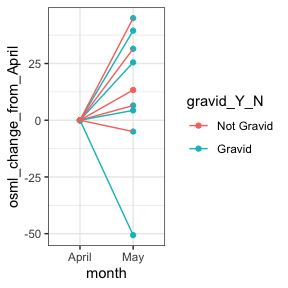

```r
ggplot(fem_change) +
  aes(x = month,
      y = osml_change_from_April,
      group = individual_ID,
      color = gravid_Y_N
      ) +
  geom_point() +
  geom_line() +
  theme_bw()
```

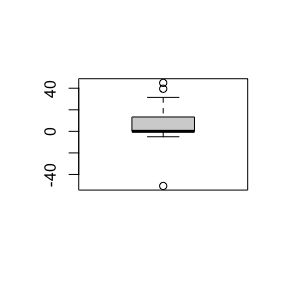

```r
boxplot(fem_change$osml_change_from_April)
```

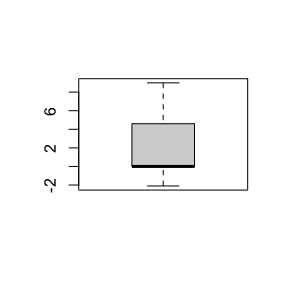

```r
boxplot(fem_change$mass_change_from_April)
```

On average, mass and osmolality both increase. There’s only one lizard who was not gravid at both time points, so we can’t compare change based on becoming gravid or not. I think it is reasonable to conclude that on average, gravid females gained mass and became less hydrated. But, we cannot say that this was DUE to gravidity, because we have nothing to compare it to

## Stats Indiv Change

Run stats tests on the change rates for only the females who were gravid in May, and use only the actual delta values, in their rows for May data.

```r
# check osml outlier range
fem_change %>%
  group_by(month) %>%
  summarise(mean(osml_change_from_April), sd(osml_change_from_April))
```

```
## # A tibble: 2 × 3
##   month `mean(osml_change_from_April)` `sd(osml_change_from_April)`
##   <fct>                          <dbl>                        <dbl>
## 1 April                            0                            0
## 2 May                             12.2                         29.0
```

```r
# for stats
fem_change_stats <- fem_change %>%
  # don't use the one female still non-gravid in May
  dplyr::filter(individual_ID != "F-12") %>%
  # only use the >resulting< change values
  dplyr::filter(month == "May") %>%
  # remove the crazy low outlier based on sd calculated above
  dplyr::filter(osml_change_from_April > (12-(29*2)))
```

ttests:

```r
t.test(fem_change_stats$CEWL_change_from_April)
```

```
##
##  One Sample t-test
##
## data:  fem_change_stats$CEWL_change_from_April
## t = -0.59229, df = 6, p-value = 0.5753
## alternative hypothesis: true mean is not equal to 0
## 95 percent confidence interval:
##  -5.873479  3.584194
## sample estimates:
## mean of x
## -1.144643
```

```r
t.test(fem_change_stats$osml_change_from_April)
```

```
##
##  One Sample t-test
##
## data:  fem_change_stats$osml_change_from_April
## t = 2.8997, df = 6, p-value = 0.02734
## alternative hypothesis: true mean is not equal to 0
## 95 percent confidence interval:
##   3.28688 38.80836
## sample estimates:
## mean of x
##  21.04762
```

```r
t.test(fem_change_stats$mass_change_from_April)
```

```
##
##  One Sample t-test
##
## data:  fem_change_stats$mass_change_from_April
## t = 3.5281, df = 6, p-value = 0.0124
## alternative hypothesis: true mean is not equal to 0
## 95 percent confidence interval:
##  1.514744 8.370970
## sample estimates:
## mean of x
##  4.942857
```

```r
t.test(fem_change_stats$SMI_change_from_April)
```

```
##
##  One Sample t-test
##
## data:  fem_change_stats$SMI_change_from_April
## t = 2.7067, df = 6, p-value = 0.03526
## alternative hypothesis: true mean is not equal to 0
## 95 percent confidence interval:
##   0.5695776 11.2980848
## sample estimates:
## mean of x
##  5.933831
```

## Stats Likelihood

Does anything correlate with the likelihood of being/becoming gravid?

Start with trying each possible logistic model to predict gravidity:

```r
repro_logit1 <- lme4::glmer(data = dat_repro_females,
                            gravid_Y_N ~ mass_g +
                            (1|individual_ID),
                            family = "binomial")

repro_logit2 <- lme4::glmer(data = dat_repro_females,
                            gravid_Y_N ~ SMI +
                            (1|individual_ID),
                            family = "binomial")

repro_logit3 <- lme4::glmer(data = dat_repro_females,
                            gravid_Y_N ~ osmolality_mmol_kg_mean +
                            (1|individual_ID),
                            family = "binomial")
```

```
## boundary (singular) fit: see help('isSingular')
```

```r
repro_logit4 <- lme4::glmer(data = dat_repro_females,
                            gravid_Y_N ~ CEWL_g_m2h +
                            (1|individual_ID),
                            family = "binomial")


car::Anova(repro_logit1, type = 2,
           test.statistic = "Chisq", error.estimate = "pearson")
```

```
## Analysis of Deviance Table (Type II Wald chisquare tests)
##
## Response: gravid_Y_N
##         Chisq Df Pr(>Chisq)
## mass_g 2.3158  1     0.1281
```

```r
car::Anova(repro_logit2, type = 2,
           test.statistic = "Chisq", error.estimate = "pearson")
```

```
## Analysis of Deviance Table (Type II Wald chisquare tests)
##
## Response: gravid_Y_N
##      Chisq Df Pr(>Chisq)
## SMI 1.3948  1     0.2376
```

```r
car::Anova(repro_logit3, type = 2,
           test.statistic = "Chisq", error.estimate = "pearson")
```

```
## Analysis of Deviance Table (Type II Wald chisquare tests)
##
## Response: gravid_Y_N
##                          Chisq Df Pr(>Chisq)
## osmolality_mmol_kg_mean 0.2219  1     0.6376
```

```r
car::Anova(repro_logit4, type = 2,
           test.statistic = "Chisq", error.estimate = "pearson")
```

```
## Analysis of Deviance Table (Type II Wald chisquare tests)
##
## Response: gravid_Y_N
##             Chisq Df Pr(>Chisq)
## CEWL_g_m2h 0.0045  1     0.9468
```

## Plot Likelihood Gravid ~ Mass

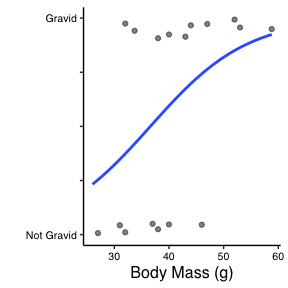

```r
dat_repro_females %>%
  # dummy-fy gravid variable
  mutate(gravid_Y_N = factor(gravid_Y_N, levels = c("Not Gravid", "Gravid"),
                             labels = c(0,1)),
         # goes 1-2, so fix to be 0-1
         gravid_Y_N = as.numeric(gravid_Y_N)-1) %>%
  # nooooowwwww I can plot and the stat_smooth will actually work
  ggplot() +
  aes(x = mass_g,
      y = gravid_Y_N) +
  geom_jitter(alpha=.5,
              position = position_jitter(height = 0.1, width = 0)
              ) +
  # must make response variable 0-1 in order for this to work
  stat_smooth(geom = "smooth",
              method = "glm",
              formula = y~x,
              se = FALSE,
              method.args = list(family = "quasibinomial")
              ) +
  ylab("") +
  scale_y_continuous(labels = c("Not Gravid", "", "", "", "Gravid"),
                     limits = c(0,1)) +
  xlab("Body Mass (g)") +
  savs_ggplot_theme
```

## Summary Figure

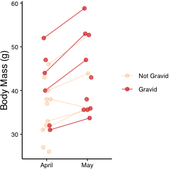

```r
dodger <- position_dodge(width = 0.2) # make dodge amt for both points and lines

dat_repro_females %>%
  # only use data for April-May
  dplyr::filter(month %in% c("April", "May")) %>%
  ggplot() +
    aes(x = month,
        y = mass_g,
        color = gravid_Y_N,
        shape = gravid_Y_N,
        alpha = gravid_Y_N,
        group = individual_ID) +
  geom_line(position = dodger) +
  geom_point(size = 2,
              position = dodger, #position_jitter(height = 0.01, width = 0),
             # alpha = 0.5
             ) +
  labs(y = "Body Mass (g)",
       x = NULL) +
  scale_color_manual(values = c(Fem_nongrav, Fem_grav), name = NULL) +
  scale_shape_manual(values = c(19, 19), name = NULL) +
  scale_alpha_manual(values = c(0.3, 0.7), name = NULL) +
  savs_ggplot_theme +
  theme(legend.position = "right",
        plot.margin = margin(t = 1.5, r = 0.5, b = 0.5, l = 0.5, unit = "pt"),
        legend.margin = margin(0,0,0,0, unit = "pt")) -> when_gravid
when_gravid
```

```r
ggsave(filename = "female_gravidity.pdf",
       plot = when_gravid,
       path = "./results_figures",
       device = "pdf",
       dpi = 600,
       units = "mm",
       #width = 200, height = 80
       width = 80, height = 60
       )
```